# Bayesian Random-effects Meta Regression

- Show All Code
- Hide All Code
- View Source

Author

Ananda Biswas

Published

November 4, 2026

## Required Libraries

**Show/Hide Code**

```r
library(openxlsx)

library(gt)
library(tidyverse)

library(cmdstanr)

library(bayesplot)
```

## Loading Data

**Show/Hide Code**

```r
df1 <- read.xlsx(data.path, sheet = 1)
```

## Initial Sanity Checks

**Show/Hide Code**

```r
str(df1)
```

```
'data.frame':   34 obs. of  10 variables:
 $ Study    : chr  "Study 1" "Study 2" "Study 3" "Study 4" ...
 $ HR.OS    : num  0.741 0.756 1.277 1.01 0.43 ...
 $ OS.ln.HR : num  -0.3 -0.28 0.244 0.01 -0.844 ...
 $ OS.se    : num  0.18 0.25 0.165 0.141 0.189 0.198 0.269 0.126 0.184 0.068 ...
 $ HR.PFS   : num  0.72 0.92 1.12 1.31 0.54 ...
 $ PFS.ln.HR: num  -0.3285 -0.0834 0.1125 0.27 -0.6162 ...
 $ PFS.se   : num  0.177 0.255 0.168 0.134 0.17 0.186 0.264 0.126 0.137 0.06 ...
 $ n1       : num  82 34 73 136 95 75 42 125 109 622 ...
 $ n2       : num  73 42 74 138 86 69 39 125 110 618 ...
 $ non.prop : chr  "0" "0" "0" "1" ...
```

**Show/Hide Code**

```r
dim(df1)
```

```
[1] 34 10
```

Snapshot of NSCLC Data

| Study | HR.OS | OS.ln.HR | OS.se | HR.PFS | PFS.ln.HR | PFS.se | n1 | n2 | non.prop |
| --- | --- | --- | --- | --- | --- | --- | --- | --- | --- |
| Study 1 | 0.7408182 | -0.3000 | 0.180 | 0.7200029 | -0.3285 | 0.177 | 82 | 73 | 0 |
| Study 2 | 0.7557837 | -0.2800 | 0.250 | 0.9199831 | -0.0834 | 0.255 | 34 | 42 | 0 |
| Study 3 | 1.2769827 | 0.2445 | 0.165 | 1.1190723 | 0.1125 | 0.168 | 73 | 74 | 0 |
| Study 4 | 1.0100502 | 0.0100 | 0.141 | 1.3099645 | 0.2700 | 0.134 | 136 | 138 | 1 |
| Study 5 | 0.4299871 | -0.8440 | 0.189 | 0.5399925 | -0.6162 | 0.170 | 95 | 86 | 1 |
| Study 6 | 0.6999825 | -0.3567 | 0.198 | 0.7499866 | -0.2877 | 0.186 | 75 | 69 | 1 |

## Derived Quantities

**Show/Hide Code**

```r
df1$weight <- 1 / (df1$OS.se)^2
```

## Generating Treatment Effect on Surrogate Endpoint in New Trials

**Show/Hide Code**

```r
range(df1$HR.PFS)
```

```
[1] 0.2034164 2.8662369
```

**Show/Hide Code**

```r
new.data <- data.frame(PFS.ln.HR = log(seq(0.2, 3, length = 1000)))
```

## Model

A random-effects meta-analysis allows for the differences in the treatment effect between studies. In a Bayesian random-effects meta-regression framework, the model can be written as

$$Y_{2i}
\sim
N\left(\mu_{2i},\sigma_{2i}^2\right),
\qquad
i=1,\ldots,N,$$

where the mean (study-specific treatment effect) is modeled as

$$\mu_{2i}
=
\lambda_{0i}
+
\lambda_1 Y_{1i}.$$

The study-specific intercepts are assumed to follow a common Normal distribution:

$$\lambda_{0i}
\sim
N\left(\beta,\psi^2\right).$$

Here:

- $Y_{1i}$ = summary measure of the treatment effect on the candidate surrogate outcome in study $i$;
- $Y_{2i}$ = summary measure of the treatment effect on the target outcome in study $i$;
- $\mu_{2i}$ = underlying true treatment effect on the target outcome in study $i$;
- $\sigma_{2i}$ = standard deviation of the estimated treatment effect $Y_{2i}$;
- $\lambda_{0i}$ = study-specific true effect on the target outcome when the treatment effect on the surrogate is zero;
- $\lambda_1$ = regression coefficient describing the relationship between treatment effects on the surrogate and target outcomes;
- $\beta$ = mean of the overarching distribution of the study-specific intercepts; and
- $\psi^2$ = between-study variance representing heterogeneity in the study-specific intercepts.

In the Bayesian framework, all parameters are given prior distributions :

$$\beta \sim N(0,10^2),$$

$$\lambda_1 \sim N(0,10^2),$$

$$\psi \sim \operatorname{Half}\text{-}t_3(0,2.5), \qquad \psi > 0,$$

and

$$\lambda_{0i}^{\mathrm{raw}} \sim N(0,1),
\qquad i=1,\ldots,N.$$

## Surrogacy Criteria

A perfect surrogate requires all the following conditions simultaneously :

- $\beta = 0$, to ensure that no treatment effect on the surrogate endpoint implies no treatment effect on the final clinical outcome
- $\lambda_1 \neq 0$, establishing a relationship between treatment effects on the surrogate and final clinical outcomes
- $\psi^2 = 0$, implying that one can predict $\mu_{2i}$ perfectly given $Y_{1i}$.

## Model Fitting

### Preparing data for STAN

**Show/Hide Code**

```r
STAN_data.BREMR <- list(
  N = nrow(df1),
  Y2 = df1$OS.ln.HR,
  Y1 = df1$PFS.ln.HR,
  sigma2 = df1$OS.se
)
```

### STAN Model

**Show/Hide Code**

```r
BREMR.model.file <- "0021__03_BREMR.stan"
```

Here is a suitable STAN model.

```stan
data {
  int<lower = 1> N;

  vector[N] Y2;
  vector[N] Y1;

  vector<lower = 0>[N] sigma2;
}

parameters {
  real beta;
  real lambda1;
  real<lower = 0> psi;

  vector[N] lambda0_raw;
}

transformed parameters {
  vector[N] lambda0;
  vector[N] mu2;

  lambda0 = beta + psi * lambda0_raw;
  mu2 = lambda0 + lambda1 * Y1;
}

model {
  // Priors
  beta ~ normal(0, 10);
  lambda1 ~ normal(0, 10);
  psi ~ student_t(3, 0, 2.5);

  lambda0_raw ~ std_normal();

  // Sampling distribution
  Y2 ~ normal(mu2, sigma2);
}

generated quantities {
  vector[N] Y2_rep;

  for (i in 1:N) {
    Y2_rep[i] = normal_rng(mu2[i], sigma2[i]);
  }
}
```

### Model Compilation

**Show/Hide Code**

```r
model.BREMR <- cmdstan_model(stan_file = BREMR.model.file)
```

### Running HMC

**Show/Hide Code**

```r
n.chains <- 4
n.samples.per.chain <- 100000
```

**Show/Hide Code**

```r
fit.BREMR <- model.BREMR$sample(
  data = STAN_data.BREMR,
  chains = n.chains,
  parallel_chains = n.chains,
  iter_warmup = 25000,
  iter_sampling = n.samples.per.chain,
  adapt_delta = 0.96,
  seed = 14,
  refresh = 0 # suppress the iteration progress messages
)
```

```
Running MCMC with 4 parallel chains...

Chain 1 finished in 35.3 seconds.
Chain 2 finished in 36.8 seconds.
Chain 4 finished in 40.9 seconds.
Chain 3 finished in 41.1 seconds.

All 4 chains finished successfully.
Mean chain execution time: 38.5 seconds.
Total execution time: 41.4 seconds.
```

**Show/Hide Code**

```r
n.posterior.samples <- n.chains * n.samples.per.chain
```

### HMC Diagnostics

**Show/Hide Code**

```r
fit.BREMR$cmdstan_diagnose()
```

```
Checking sampler transitions treedepth.
Treedepth satisfactory for all transitions.

Checking sampler transitions for divergences.
No divergent transitions found.

Checking E-BFMI - sampler transitions HMC potential energy.
E-BFMI satisfactory.

Rank-normalized split effective sample size satisfactory for all parameters.

Rank-normalized split R-hat values satisfactory for all parameters.

Processing complete, no problems detected.
```

### Posterior Predictive Check - PPC

It is a way of checking whether my Bayesian model can generate data that look reasonably similar to the data I actually observed.

Suppose we observe $n$ data-points. For each posterior draw of the parameters, we draw a random sample of $n$ data-points.

Here in NSCLC data-set, there are $34$ studies. So we shall have $400000$ replicated data-sets, each having $34$ studies.

**Show/Hide Code**

```r
Y2.replicated.draws <- fit.BREMR$draws(variables = "Y2_rep", format = "matrix")

dim(Y2.replicated.draws)
```

```
[1] 400000     34
```

### Check 1

Plot the density of the observed data and densities of a few randomly selected replicated data-sets to assess the Bayesian model.

**Show/Hide Code**

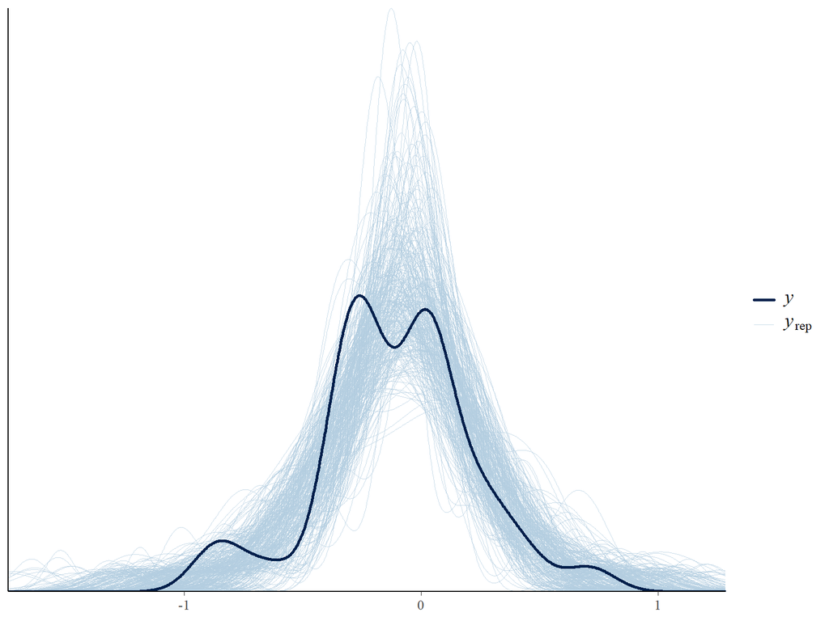

```r
# a few randomly selected replications
temp <- sample(1:n.posterior.samples, 300)

ppc_dens_overlay(y = df1$OS.ln.HR,
                 yrep = Y2.replicated.draws[temp, ])
```

### Check 2

Plot the observed `y~x` along with the prediction intervals calculated from the replications of each `y`.

For instance, here I shall have $34$ points each corresponding to a study in the NSCLC data, and $34$ prediction intervals accompanying them. Prediction interval for $Y_{2j}$ was calculated from the $400000$ replications of $Y_{2j}$ $\forall j = 1(1)34$.

**Show/Hide Code**

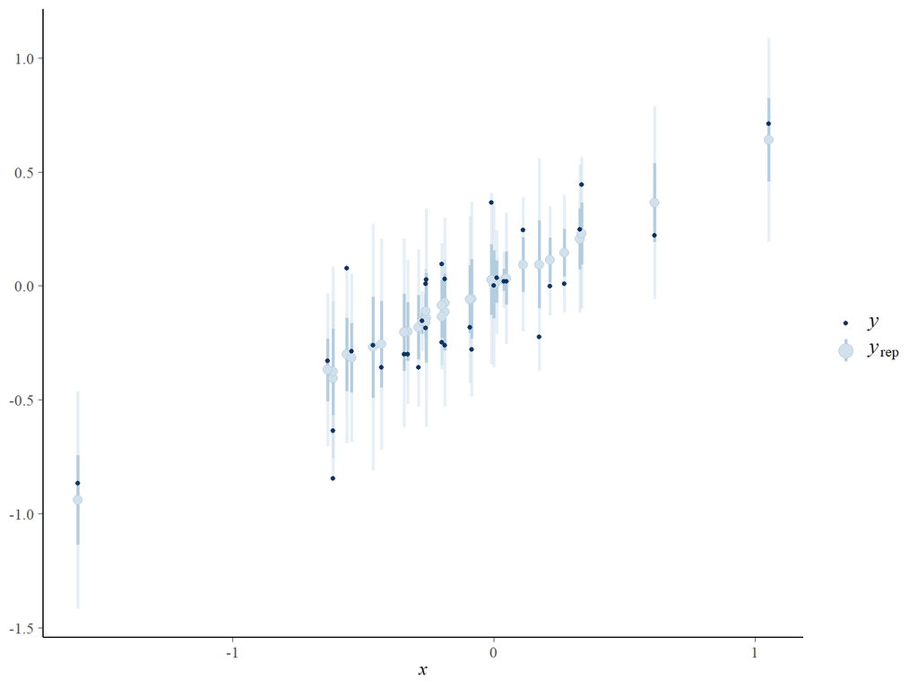

```r
ppc_intervals(y = df1$OS.ln.HR,
              yrep = Y2.replicated.draws,
              x = df1$PFS.ln.HR)
```

In the above, the wide outer bands often contain the dark dots, with just one or two falling on the extreme ends.

## Posterior Summaries of Parameters of Interest

### Point Estimates

**Show/Hide Code**

```r
fit.BREMR$summary(variables = c("beta", "lambda1", "psi")) |>
  gt()
```

| variable | mean | median | sd | mad | q5 | q95 | rhat | ess_bulk | ess_tail |
| --- | --- | --- | --- | --- | --- | --- | --- | --- | --- |
| beta | 0.00616647 | 0.006436384 | 0.03098774 | 0.03029207 | -0.045084978 | 0.05638399 | 1.000001 | 375184.5 | 278713.4 |
| lambda1 | 0.59735386 | 0.596829515 | 0.08848564 | 0.08798454 | 0.452964010 | 0.74303965 | 1.000022 | 448201.0 | 301876.9 |
| psi | 0.05405832 | 0.047731504 | 0.03840018 | 0.03966830 | 0.004695054 | 0.12576372 | 1.000027 | 132630.3 | 196893.1 |

Posterior means/medians can be used as Bayesian estimates of the parameters.

### Interval Estimates

**Show/Hide Code**

```r
posterior.draws <- fit.BREMR$draws(
  variables = c("beta", "lambda1", "psi"),
  format = "matrix"
)
```

**Show/Hide Code**

```r
apply(posterior.draws, 2, quantile, probs = c(0.025, 0.975))
```

```
       variable
               beta   lambda1         psi
  2.5%  -0.05567013 0.4243610 0.002366023
  97.5%  0.06643179 0.7715739 0.142565791
```

### Distribution of the heterogeneity parameter

**Show/Hide Code**

```r
psi.draws <- fit.BREMR$draws(variables = "psi", format = "draws_df")
```

**Show/Hide Code**

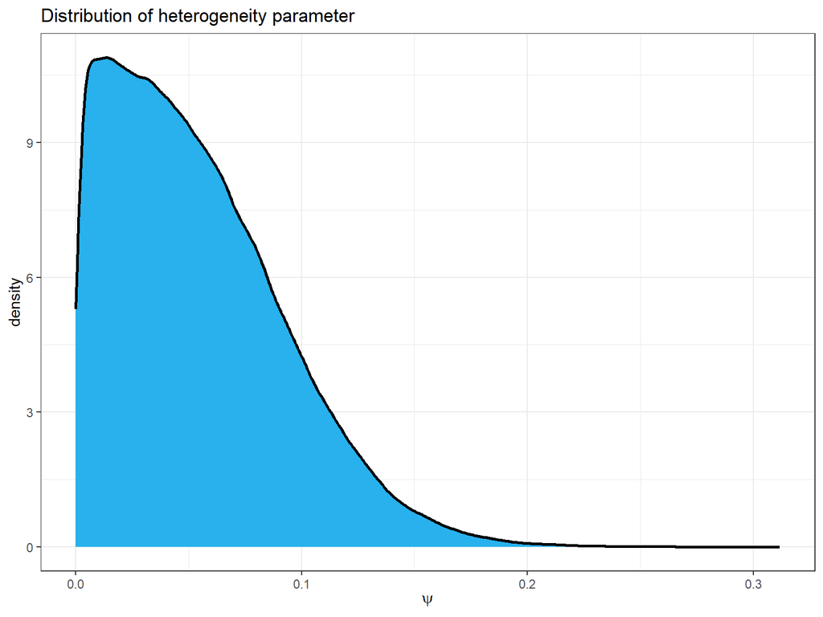

```r
psi.draws %>%
  ggplot(aes(x = psi)) +
  geom_density(linewidth = 1, fill = "#28B1ED") +
  labs(x = expression(psi),
       title = "Distribution of heterogeneity parameter") +
  theme_bw() +
  scale_colour_hue("trial")
```

## Prediction of TE on Clinical Outcome in New Trials

Now use posterior samples to calculate the predictions on new future trials, credible intervals and prediction intervals. These are the main components of **trial-level association plot**.

**Show/Hide Code**

```r
data.frame(head(posterior.draws)) |>
  gt()
```

Preview of Posterior Sample

| beta | lambda1 | psi |
| --- | --- | --- |
| -0.027832180 | 0.5960663 | 0.074422884 |
| 0.008509057 | 0.7067940 | 0.000448917 |
| -0.004752082 | 0.4305766 | 0.069275141 |
| -0.001093526 | 0.4162878 | 0.037941912 |
| 0.066206158 | 0.6418360 | 0.017891678 |
| -0.007769676 | 0.7455469 | 0.022990682 |

**Show/Hide Code**

```r
dim(posterior.draws)
```

```
[1] 400000      3
```

Each row of `posterior.draws` is a posterior sample from the joint posterior distribution of the parameters.

Now I create a design matrix `X` representing new studies on which we will make future predictions.

**Show/Hide Code**

```r
X <- matrix(c(rep(1, 1000), new.data$PFS.ln.HR),
            nrow = 1000, ncol = 2, byrow = FALSE)
```

For each new trial in `X`, corresponding to $400000$ posterior samples of the parameters, there will be $400000$ predictions of `log.HR.OS`. Below I do a matrix operation to obtain all the $1000 \times 400000$ predictions.

**Show/Hide Code**

```r
BREMR.posterior <- X %*% t(posterior.draws[,1:2])
```

**Show/Hide Code**

```r
dim(BREMR.posterior)
```

```
[1]   1000 400000
```

Each row of `BREMR.posterior` represents $400000$ posterior draws of `log.HR.OS` *i.e.* the response variable, corresponding to a new `log.HR.PFS` of a new trial.

### Point Estimates

For a new trial, to get a prediction of `log.HR.OS`, we must calculate the mean of the posterior samples.

**Show/Hide Code**

```r
BREMR.fit <- apply(BREMR.posterior, 1, mean)
```

`BREMR.fit` has $1000$ predictions corresponding to $1000$ new future trials.

### Credible Intervals

Credible intervals are obtained from the quantiles of the posterior distribution. Here I calculate the $95\%$ credible intervals for the predictions on new trials.

**Show/Hide Code**

```r
BREMR.ci <- t(apply(BREMR.posterior, 1, quantile, probs = c(0.025, 0.975)))
```

### Prediction Intervals

Prediction intervals are obtained from the quantiles of the posterior predictive distribution.

The posterior distribution of concern here is

$$p\left(\beta, \lambda_1, \psi \mid Y_{11}, Y_{21}, Y_{12}, Y_{22}, \ldots, Y_{1N}, Y_{2N}\right).$$
Already I have $400000$ samples from this posterior distribution.

We want the predictive distribution of $\widehat{\mu_{2 \cdot \text{new}}}:$ the true treatment effect on clinical outcome in a future trial.

In any future trial, let $Y_{1 \cdot \text{new}}$ be the observed treatment effect on surrogate endpoint. Then we must have

$$\widehat{\mu_{2 \cdot \text{new}}} \sim \mathcal{N}\left( \beta + \lambda_1 Y_{1 \cdot \text{new}}, \psi^2\right).$$

In Bayesian theory, the predictive distribution is obtained by averaging the likelihood over the entire parameter space where the parameters vary in accordance to the posterior distribution.

Mathematically, we can write the posterior predictive distribution as

$$\displaystyle{\int \limits_{(\beta, \lambda_1, \psi)}} \mathcal{N}\left( \beta + \lambda_1 Y_{1 \cdot \text{new}}, \psi^2\right) \cdot p\left(\beta, \lambda_1, \psi \mid \cdots \right) d\beta \; d\lambda_1 \; d\psi.$$

As analytical solution cannot be traced, we resort to numerical solution as follows :

- Using posterior sample $(\beta_{(m)}, \lambda_{1(m)}, \psi_{(m)})$ calculate $\beta_{(m)} + \lambda_{1(m)} Y_{1 \cdot \text{new}}$ $\forall m = 1(1)400000$.
- Take a random sample from $\mathcal{N}\left(\beta_{(m)} + \lambda_{1(m)}, \psi_{(m)}^2 \right)$ $\forall m = 1(1)400000$.
- Calculate $q_{0.025}$, $q_{0.975}$ for the random samples just obtained.
- Repeat the above $3$ for all the new trials to get predictive interval around their predictions.

Now I proceed to calculate the $95\%$ posterior prediction intervals.

**Show/Hide Code**

```r
u <- rnorm(n.posterior.samples, 0, sd = posterior.draws[,3])

BREMR.predictions <- BREMR.posterior +
                     matrix(rep(u, 1000),
                            nrow = 1000,
                            ncol = n.posterior.samples,
                            byrow = TRUE)
```

**Show/Hide Code**

```r
BREMR.pi <- t(apply(BREMR.predictions, 1, quantile, probs = c(0.025, 0.975)))
```

## Trial-level Association Plot

I combine all the required components for the trial-level association plot.

**Show/Hide Code**

```r
BREMR.pred.df <- data.frame(HR.OS = exp(BREMR.fit),
                            HR.PFS = exp(new.data$PFS.ln.HR),
                            lower.ci = exp(BREMR.ci[,1]),
                            upper.ci = exp(BREMR.ci[,2]),
                            lower.pi = exp(BREMR.pi[,1]),
                            upper.pi = exp(BREMR.pi[,2]))
```

**Show/Hide Code**

```r
BREMR.association.plot <- ggplot(df1, aes(x = HR.PFS, y = HR.OS)) +
  geom_ribbon(aes(x = HR.PFS, ymin = lower.ci, ymax = upper.ci), data = BREMR.pred.df, alpha = 0.6, fill = "steelblue") +
  geom_ribbon(aes(x = HR.PFS, ymin = lower.pi, ymax = upper.pi), data = BREMR.pred.df, alpha = 0.4, fill = "lightblue") +
  geom_line(aes(x = HR.PFS, y = HR.OS), data = BREMR.pred.df,
            col = "steelblue", linewidth = 1, stat = 'identity') +
  geom_point(aes(size = weight), col = "gray30", fill = "orange", shape = 21, data = df1) +
  scale_x_continuous(transform = "log",
                     limits = c(0.2, 3.1),
                     breaks=c(0.1,0.2,0.3,0.4,0.5,0.7,1,1.2,1.5,2,3),
                     expand = c(0.01, 0.01)) +
  scale_y_continuous(transform = "log",
                     limits = c(0.2, 3.1),
                     breaks=c(0.1,0.2,0.3,0.4,0.5,0.7,1,1.2,1.5,2,3),
                     expand = c(0.01, 0.01)) +
  geom_hline(yintercept = 1, linetype = "dashed") +
  xlab("Progression-free survival hazard ratio (log scale)")+
  ylab(paste("Overall survival hazard ratio" , "\n", "\U00B1", "95% credible and prediction intervals (log scale)")) +
  ggtitle("Bayesian Random-effects Meta-regression") +
  theme_bw() +
  scale_colour_hue("trial") +
  theme(legend.position = "none")
```

**Show/Hide Code**

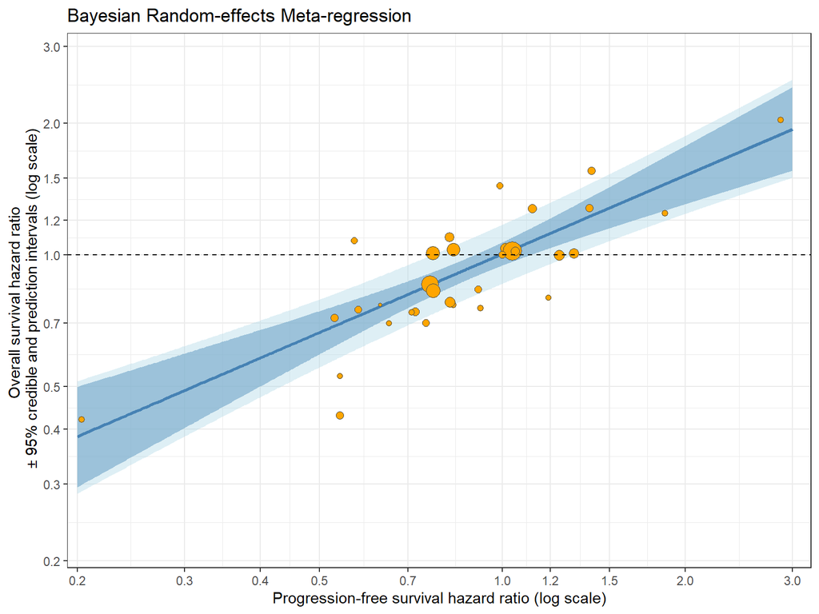

```r
BREMR.association.plot
```

## Surrogate Threshold Effect

Surrogate Threshold Effect is defined as *the minimum treatment effect on the surrogate necessary to predict a nonzero effect on the true endpoint* in a future trial. $\log(HR) < 0$ implies a *beneficial* treatment effect. So STE was computed as the intersection of the upper $95\%$ prediction interval with the horizontal line for no treatment effect (i.e., in which the HR for OS equals $1$ or $\log(HR) = 0$).

**Show/Hide Code**

```r
candidate.HR.PFS <- BREMR.pred.df %>%
  filter(upper.pi < 1) %>%
  pull(HR.PFS)

BREMR.STE <- round(max(candidate.HR.PFS), digits = 3)
BREMR.STE
```

```
[1] 0.766
```

## Leave-one-out Cross-validation

Leave-one-out cross-validation (LOOCV) is performed by selecting each trial in a data set in turns and using it as the validation set while using the rest $(n-1)$ of the trials as the training set. This is repeated $n$ times. For each iteration in the LOOCV procedure, models are ﬁtted to the training set, and the dependent variable of interest (target endpoint) is predicted on the basis of the explanatory variable(s) in the models (surrogate endpoint) in the validation set.

Two different criteria were used to assess the performance of each model for each iteration of the LOOCV. For each criterion, the median and range of the output values were used to assess model performance.

### Proportion of actual values from the validation set that lies within the 95% prediction interval from the training set

The steps are as follows:

- Leave out $i-$th study and train the model with remaining $n - 1$ studies.
- Obtain $95\%$ prediction interval for the treatment effect on target endpoint (OS) in the left-out trial, using its surrogate endpoint (PFS) treatment effect.
- Simulate $1000$ OS treatment effects based on normal distribution using the observed OS treatment effect and its standard error from the left-out trial.
- Calculate the proportion of the $1000$ simulated values falling within the prediction interval, $p_i$.
- Repeat these steps for all the studies, leaving out one at a time.
- Calculate $median(p_1, \ldots, p_n)$ and $range(p_1, \ldots, p_n)$.

**Show/Hide Code**

```r
n <- nrow(df1)

prop <- c()

absolute.difference <- c()
```

**Show/Hide Code**

```r
for(i in 1:n){
  df <- df1[-i,]

  BREMR.data <- list(N = nrow(df),
                     Y2 = df$OS.ln.HR, Y1 = df$PFS.ln.HR,
                     sigma2 = df$OS.se)

  fit.BREMR <- model.BREMR$sample(data = BREMR.data,
                                  chains = 4, parallel_chains = 4,
                                  iter_warmup = 250,
                                  iter_sampling = 1000,
                                  adapt_delta = 0.96,
                                  seed = 14,
                                  refresh = 0)

  posterior.draws <- fit.BREMR$draws(variables = c("beta", "lambda1", "psi"),
                                     format = "draws_df")

  new.data <- data.frame(PFS.ln.HR = df1$PFS.ln.HR[i])

  BREMR.posterior <- posterior.draws$beta + new.data$PFS.ln.HR * posterior.draws$lambda1

  u <- rnorm(4 * 1000, 0, sd = posterior.draws$psi)

  BREMR.predictions <- BREMR.posterior + u

  # for criterion 1
  BREMR.pi <- quantile(BREMR.predictions, probs = c(0.025, 0.975))

  simulated.OS.ln.HR <- rnorm(1000, mean = df1$OS.ln.HR[i], sd = df1$OS.se[i])

  prop[i] <- mean((simulated.OS.ln.HR >= BREMR.pi["2.5%"]) & (simulated.OS.ln.HR <= BREMR.pi["97.5%"]))

  # for criterion 2
  BREMR.fit <- mean(BREMR.predictions)

  absolute.difference[i] <- abs(df1$OS.ln.HR[i] - BREMR.fit)
}
```

**Show/Hide Code**

```r
median.prop <- median(prop)
median.prop
```

```
[1] 0.4645
```

**Show/Hide Code**

```r
range.prop <- range(prop)
range.prop
```

```
[1] 0.033 0.996
```

### Absolute difference between mean predicted value and actual value

The absolute difference between the actual log hazard ratio and the predicted log hazard ratio for OS for each trial left out will be recorded.

**Show/Hide Code**

```r
median.absolute.difference <- median(absolute.difference)
median.absolute.difference |> round(3)
```

```
[1] 0.144
```

**Show/Hide Code**

```r
range.absolute.difference <- range(absolute.difference)
range.absolute.difference |> round(3)
```

```
[1] 0.005 0.518
```